# brain_trabajo

### 3.4.3. Selección de variables con FSRankingDA

Se estudia en esta sección la clasificación para el ranking creado con DA.

```r
# Evaluar biomarcadores en TRN. Es multiclase, mejor ver accuracy y F1-Score
logistic_trn_da<- logistic_trn2(MLMatrix, MLLabels, vars_selected = names(FSRankingDA[1:10]))
```

```r
logistic_results_da <- rbind(logistic_trn_da$F1Info$meanF1[1:10],logistic_trn_da$accuracyInfo$meanAccuracy)
#dataPlot(svm_results_da, MLLabels, legend = c("F1","Accuracy"), mode = "classResults", xlab="Genes", ylab="Prediction Score")
```

```r
# Evaluar huella genética en TEST. Es multiclase, mejor ver accuracy y F1-Score
logistic_test_da <- logistic_test_multiclase(MLMatrix, MLLabels, t(XTest), YTest, vars_selected = names(FSRankingDA[1:10]), logistic_trn_da)
logistic_results_da_test <- rbind(logistic_trn_da$F1Info$meanF1[1:10], logistic_test_da$f1Vector, logistic_trn_da$accuracyInfo$meanAccuracy, logistic_test_da$accVector)
```

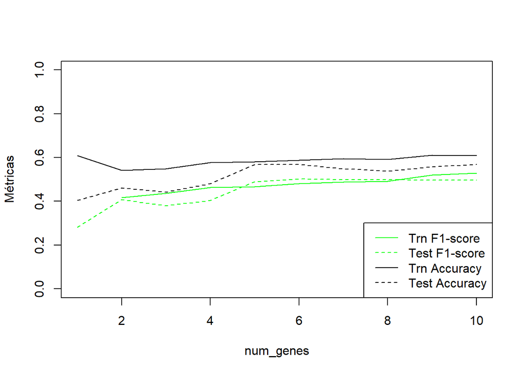

A partir de 5 genes, parece que las métricas de train y test dejan de tener altibajos. Destaca que estas métricas son más bajas que los resultados obtenidos con los rankings mRMR y RF. Veamos la matriz de confusión para el conjunto test para facilitar la obtención de conclusiones:

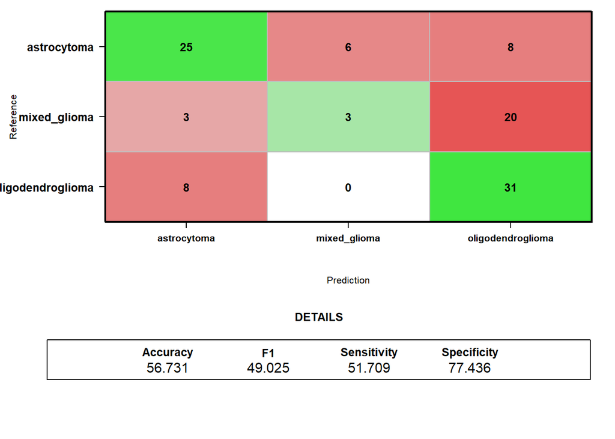

La bajada de precisión y de F1 score es debido a la gran confusión del glioma mixto con el oligodendroglioma.

### 3.4.3. Selección de variables con FSRanking_MB

Por último, repitamos el estudio para el ranking de Markov Blanket, entrenando los modelos `logistic_trn_mb` y `logistic_test_mb.`

```r
logistic_trn_mb <- logistic_trn2(MLMatrix, MLLabels, vars_selected = FSRanking_MB[1:10])
save(logistic_trn_mb, file='logistic_trn_mb')
```

```r
load('logistic_trn_mb')
```

```r
logistic_results_mb <- rbind(logistic_trn_mb$F1Info$meanF1[1:10],logistic_trn_mb$accuracyInfo$meanAccuracy)
logistic_test_mb <- logistic_test_multiclase(MLMatrix, MLLabels, t(XTest), YTest, vars_selected = (FSRanking_MB[1:10]), logistic_trn_mb)
```

```
## Probando con 2 variables...
## Probando con 3 variables...
## Probando con 4 variables...
## Probando con 5 variables...
## Probando con 6 variables...
## Probando con 7 variables...
## Probando con 8 variables...
## Probando con 9 variables...
## Probando con 10 variables...
## ¡Clasificación realizada con éxito!
```

```r
logistic_results_mb_test <- rbind(logistic_trn_mb$F1Info$meanF1[1:10], logistic_test_mb$f1Vector, logistic_trn_mb$accuracyInfo$meanAccuracy, logistic_test_mb$accVector)
```

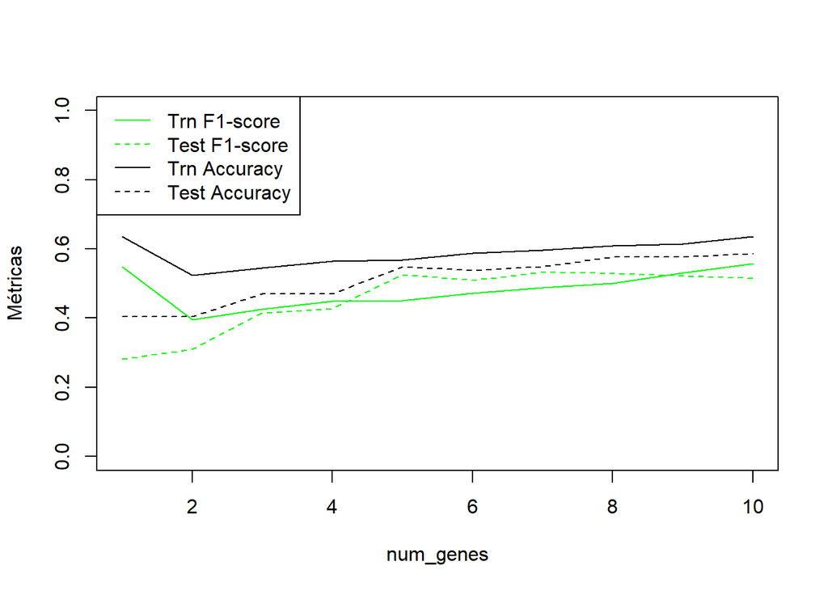

De nuevo, parece adecuado escoger una huella de 5 genes ya que seha btenido una gráfica muy silimar a la anterior, pero no igual. Por ello, calculemos la matriz de confusión para el conjunto test y esta huella para visulizar los resultados con más detalle:

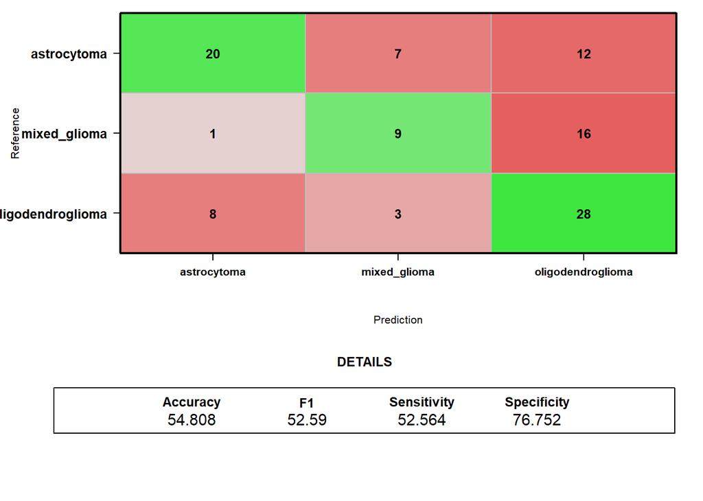

Es cuarioso ya que es una de la mejores clasificaciones de la clase glioma mixto. Sin emebargo, se confunde en bastantes ocasiones el glioma mixto y el astrocitoma con el oligodendroglioma.

### 3.4.5. Conclusiones

# 4. Resultados bajo el algoritmo de selección y clasificador escogidos en 5CV

En la siguiente sección, se seleccionará la combinación óptima de algoritmo de selección y clasificador, con vista a la sección anterior, y se validará su rendimiento utilizando una validación cruzada de 5 particiones (5CV). Se evaluará el desempeño del modelo en los conjuntos de entrenamiento (Train) y prueba (Test) mediante gráficos que muestran la evolución del número de genes seleccionados y los resultados medios en las cinco particiones. Además, se proporcionarán los cinco rankings de genes más relevantes y se escogerá la huella génica final basada en su consistencia y relevancia.

En primer lugar, el algoritmo de selección de variables elegido es el **mRMR** y el clasificador será **Regresión Logística múltime con penalización**; ya que es con el que se ha obtenido mejores valores de Accuracy, F1, sensibilidad y especificidad.

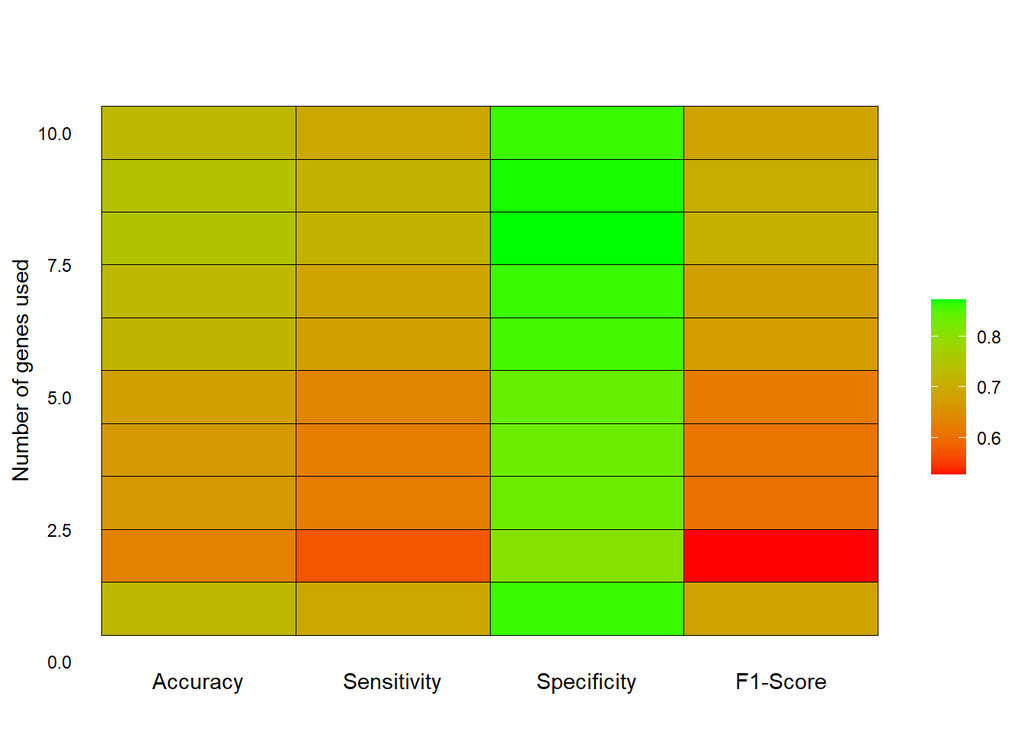

En segundo lugar, se presenta el siguiente código con el objetivo de mostar resultado, para el modelo de regresión logística con una penalización de $decay = 10^{-4}$ (la objetenida con el modelo `logistic_trn_mrmr` en la sección anterior) y utilizando el seleccionador de características mRMR, en 5CV Trn-Test para todo el dataset:

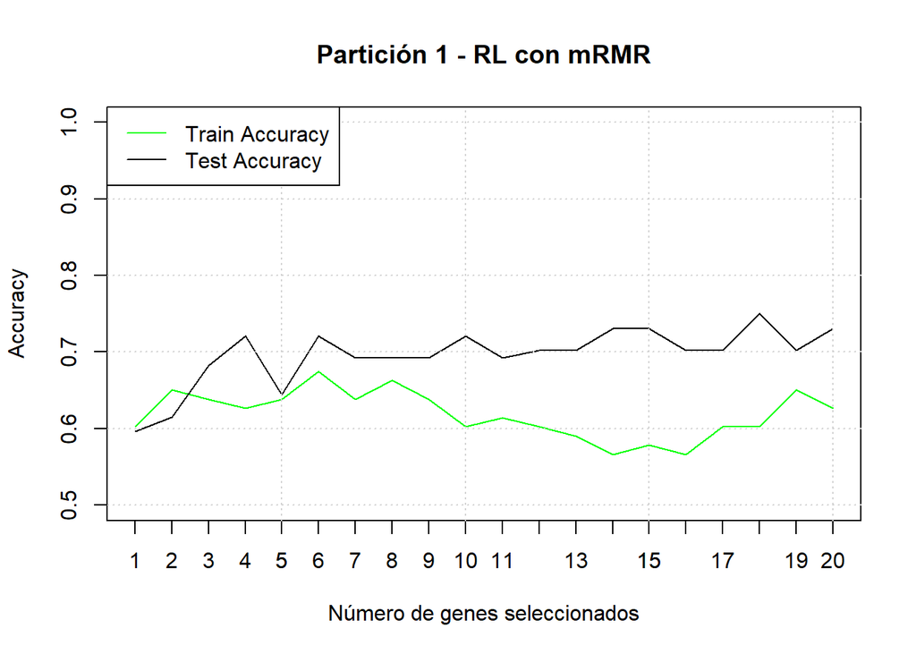

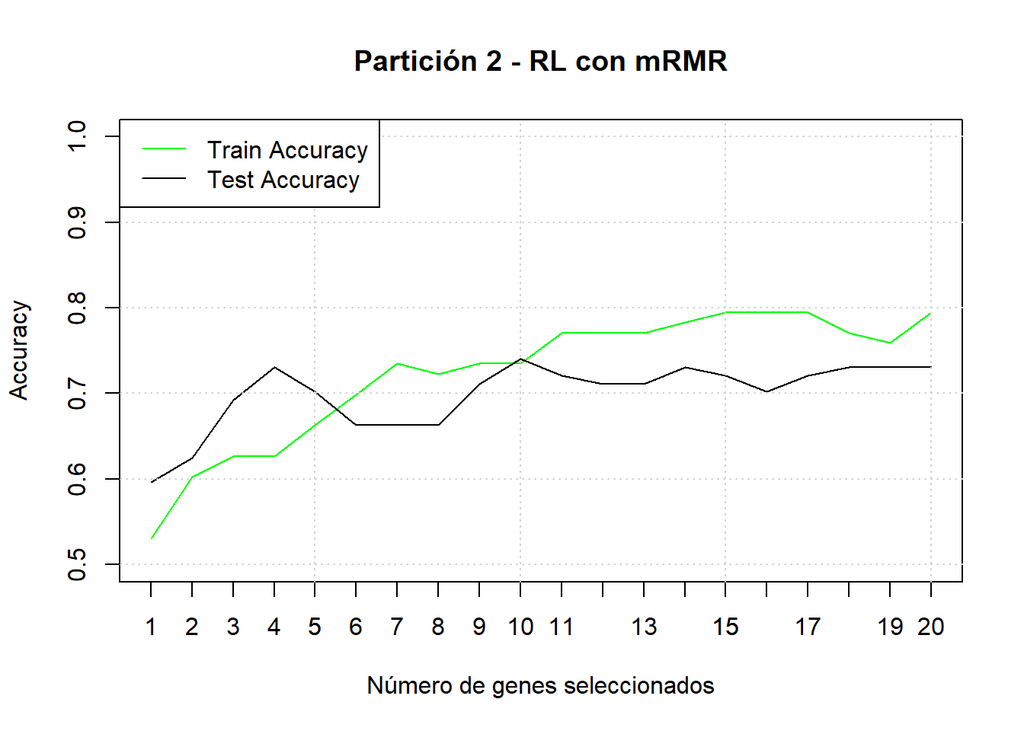

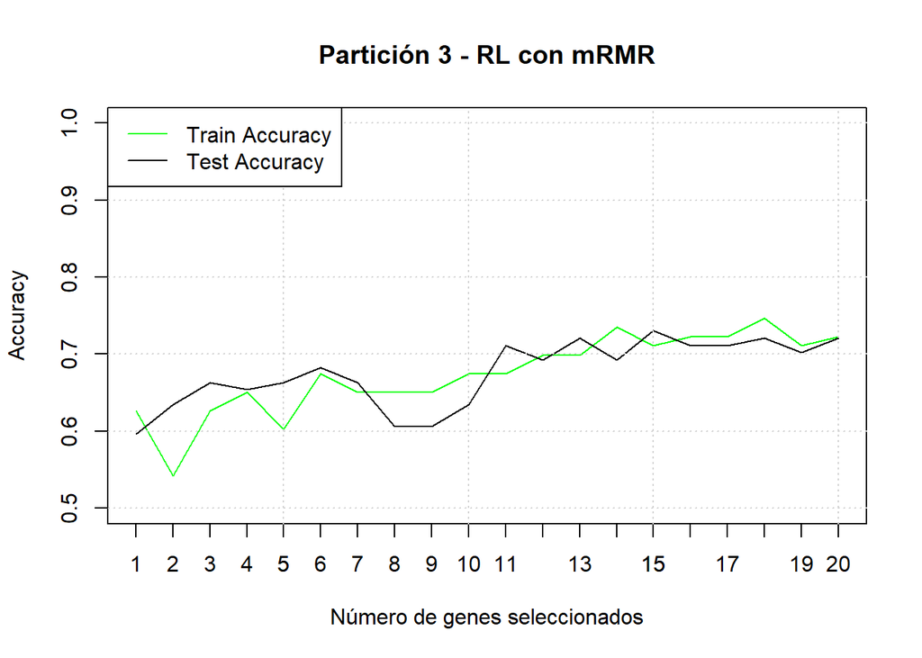

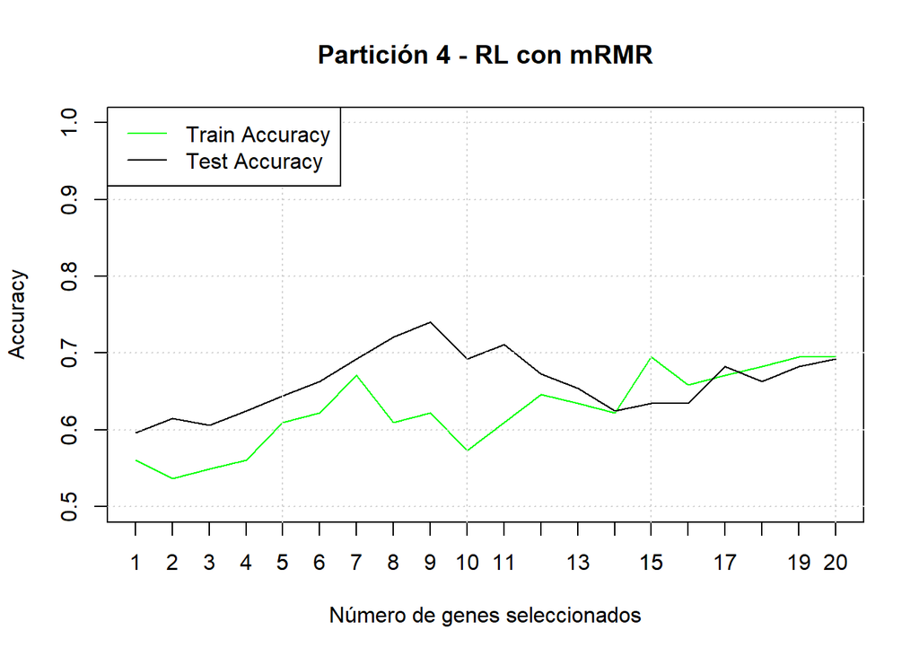

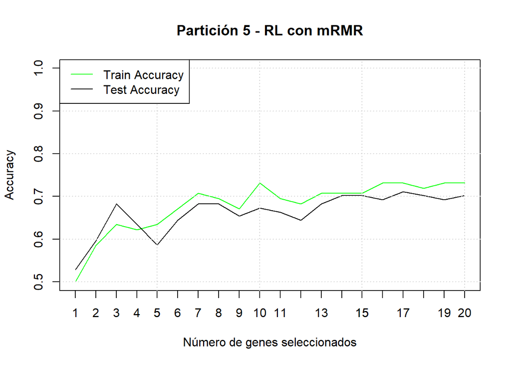

```r
set.seed(19)

nfolds <- 5  # Número de particiones en la validación cruzada
foldIDx <- cvGenStratified(MLLabels, nfolds)  # Particiones estratificadas

nVarsMAX <- 20  # Número máximo de genes a seleccionar, en un ejercicio de clase se aumentó hasta 50

# Matrices para almacenar métricas por partición
ACCTrnRL <- matrix(0, nfolds, nVarsMAX)
ACCTestRL <- matrix(0, nfolds, nVarsMAX)


# Para almacenar los ranking de características de cada partición
rankingSMRMR <- matrix(0, nfolds, nVarsMAX)

# El Mejor hiperparámetro decay obtenido en la sección enterior
best_decay<-logistic_trn_mrmr$logisticModel$finalModel$decay
print(best_decay)

# Bucle para 5 particiones
for (particion in seq(1, nfolds)) {
  # Crear particiones de entrenamiento y prueba
  datosParaTRN <- which(foldIDx != particion)  # Índices de entrenamiento
  segmentoTest <- which(foldIDx == particion)  # Índices de prueba

  XTrn_P <- as.data.frame( MLMatrix[datosParaTRN, ] ) # Datos de entrenamiento
  XTest_P <- as.data.frame(MLMatrix[segmentoTest, ])  # Datos de prueba

  YTrn_P <- as.factor(MLLabels[datosParaTRN])  # Etiquetas de entrenamiento
  YTest_P <- as.factor(MLLabels[segmentoTest])  # Etiquetas de prueba

  # Ranking con mRMR
  rankingMRMR <-featureSelection(XTrn_P, YTrn_P, mode = "mrmr", vars_selected = colnames(XTrn_P))

  # Guardar POR FILAS el ranking de características para esta partición
  rankingSMRMR[particion, ] <- rankingMRMR[1:nVarsMAX]


  # Evaluación por número de genes seleccionados
  for (numGenes in seq_len(nVarsMAX)) {
    # Seleccionar las mejores variables
    topGenes <- colnames(XTrn_P)[rankingMRMR[1:numGenes]]

    # Entrenar modelo Regresión Logística multinomial
    modelo <- multinom(YTrn_P ~ ., data = subset(XTrn_P, select=topGenes), decay = best_decay)

    # Predicciones en Train
    predTrain <- predict(modelo, subset(XTest_P, select=topGenes))
    confMatTrain <- confusionMatrix(as.factor(predTrain), as.factor(YTest_P))
    ACCTrnRL[particion, numGenes] <- confMatTrain$overall["Accuracy"]

    # Predicciones en Test
    predTest <- predict(modelo, subset(t(XTest), select=topGenes))
    confMatTest <- confusionMatrix(as.factor(predTest), as.factor(YTest))
    ACCTestRL[particion, numGenes] <- confMatTest$overall["Accuracy"] # se van añadiendo los valores por filas. Por tanto, para calcular la media de los accuracy para un número determinado de genes que hacerlo por columnas.  #print(confMatTest$overall[1])
    #print(confMatTest$table)
  }

  # Graficar los resultados para la partición actual
  num_genes <- 1:nVarsMAX
  Trn_Acc <- ACCTrnRL[particion, 1:nVarsMAX]
  Test_Acc <- ACCTestRL[particion, 1:nVarsMAX]

  plot(num_genes, Trn_Acc, type = "l", col = "green", ylim = c(0.5, 1), ylab = "Accuracy",        xlab = "Número de genes seleccionados", main = paste("Partición", particion, "- RL con mRMR"))
  lines(num_genes, Test_Acc, col = "black")
  axis(1, at = 1:20, labels = 1:20)  # Configura los ticks y etiquetas del eje X
  grid()
  legend("topleft", legend = c("Train Accuracy", "Test Accuracy"),col=c("green","black"),lty = c(1, 1))
}
```

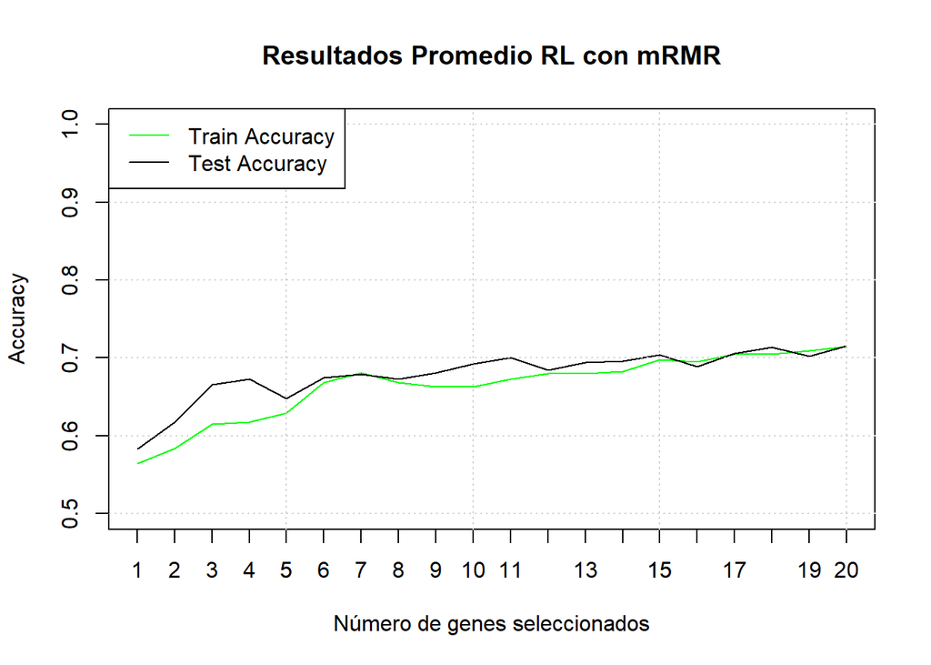

```r
# Medias de Accuracy en las 5 particiones
ACCTrnRL_Mean <- colMeans(ACCTrnRL)
ACCTestRL_Mean <- colMeans(ACCTestRL)

# Resultados promedio
plot(1:nVarsMAX, ACCTrnRL_Mean, type = "l", col = "green", ylim = c(0.5, 1), xlim=c(1,20), xlab = "Número de genes seleccionados", ylab = "Accuracy", main = "Resultados Promedio RL con mRMR")
lines(1:nVarsMAX, ACCTestRL_Mean, col = "black")
axis(1, at = 1:20, labels = 1:20)  # Configura los ticks y etiquetas del eje X
grid()
legend("topleft", legend = c("Train Accuracy", "Test Accuracy"), col = c("green", "black"),
       lty = c(1, 1))
```

```r
ACCTrnRL_Mean
```

```
##  [1] 0.5640024 0.5834264 0.6148986 0.6173083 0.6295034 0.6681751 0.6804290
##  [8] 0.6682045 0.6633559 0.6633852 0.6730238 0.6803115 0.6803409 0.6827211
## [15] 0.6973553 0.6949163 0.7045842 0.7045842 0.7094622 0.7142815
```

```r
ACCTestRL_Mean
```

```
##  [1] 0.5826923 0.6173077 0.6653846 0.6730769 0.6480769 0.6750000 0.6788462
##  [8] 0.6730769 0.6807692 0.6923077 0.7000000 0.6846154 0.6942308 0.6961538
## [15] 0.7038462 0.6884615 0.7057692 0.7134615 0.7019231 0.7153846
```

```r
# Se observan la variable rankingSMRMR
rankingSMRMR[,1:5]
```

```
##      [,1] [,2] [,3] [,4] [,5]
## [1,]  170   81   51  138   41
## [2,]  170   51   81   10   69
## [3,]  170   10   51  105   28
## [4,]  170   62   81   16   21
## [5,]   81   51  170   34    7
```

```r
# rankingMRMR de la última iteración pero solo lo utilizamos para saber el nombre de los genes
colnames(MLMatrix)[c(170, 81, 51, 41, 10)]
```

```
## [1] "IGHV3-73" "IGHV6-1"  "UBQLN4P1" "RAPH1"    "PI4K2B"
```

```r
# Se observan la variable rankingSMRMR
rankingSMRMR[,1:10]
```

```
##      [,1] [,2] [,3] [,4] [,5] [,6] [,7] [,8] [,9] [,10]
## [1,]  170   81   51  138   41   22  194  158   95    28
## [2,]  170   51   81   10   69  124   41  105   16   106
## [3,]  170   10   51  105   28  106   41  181   81    16
## [4,]  170   62   81   16   21   10   51  127  139    55
## [5,]   81   51  170   34    7   22   10   95  106    41
```

```r
# rankingMRMR de la última iteración pero solo lo utilizamos para saber el nombre de los genes
colnames(MLMatrix)[c(170, 81, 51, 41, 10)]
```

```
## [1] "IGHV3-73" "IGHV6-1"  "UBQLN4P1" "RAPH1"    "PI4K2B"
```

## 4.1. Resultado de la huella final escogida y clasificador en 5 CV, matriz de confusión final del dataset.

Podemos comenzar esta sección calculando la matriz final del modelo conocida la huella volviendo a probar en 5CV con el número de genes escogidos, es decir, *numGenes <- 5*:

```r
set.seed(19)

nfolds <- 5  # Número de particiones en la validación cruzada
foldIDx <- cvGenStratified(LABELS, nfolds)  # Particiones estratificadas

# Vectores para almacenar métricas por partición
ACCTrnRL <- numeric(nfolds)
ACCTestRL <- numeric(nfolds)

# Matriz de confusión acumulada para el test
accTestSum <- matrix(0, nrow = 3, ncol = 3)

# Ranking con mRMR
huella <- c("IGHV3-73", "IGHV6-1", "UBQLN4P1", "PI4K2B", "RAPH1")

# Bucle para 5 particiones
for (particion in seq_len(nfolds)) {
  # Crear particiones de entrenamiento y prueba
  datosParaTRN <- which(foldIDx != particion)  # Índices de entrenamiento
  segmentoTest <- which(foldIDx == particion)  # Índices de prueba

  XTrn_P <- as.data.frame(t(MATRIZ[,datosParaTRN])) # Datos de entrenamiento
  XTest_P <- as.data.frame(t(MATRIZ[,segmentoTest]))  # Datos de prueba

  YTrn_P <- as.factor(LABELS[datosParaTRN])  # Etiquetas de entrenamiento
  YTest_P <- as.factor(LABELS[segmentoTest])  # Etiquetas de prueba


  # Entrenar modelo Regresión Logística multinomial
  modelo <- multinom(YTrn_P ~ ., data = subset(XTrn_P, select=huella), decay = best_decay)

  # Predicciones en Test
  predTest <- predict(modelo, XTest_P[, huella])
  confMatTest <- confusionMatrix(as.factor(predTest), YTest_P)
  #print(confMatTest$table)
  ACCTestRL[particion] <- confMatTest$overall["Accuracy"]


  # Sumar la matriz de confusión al total
  accTestSum <- accTestSum + confMatTest$table
}
```

```r
print("Matriz de confusión acumulada en el test:")
```

```
## [1] "Matriz de confusión acumulada en el test:"
```

```r
accTestSum
```

```
##                    Reference
## Prediction          astrocytoma mixed_glioma oligodendroglioma
##   astrocytoma               162           34                 8
##   mixed_glioma               17           38                32
##   oligodendroglioma          13           60               153
```

```r
table(LABELS)
```

```
## LABELS
##       astrocytoma      mixed_glioma oligodendroglioma
##               192               132               193
```

Finalmente, con estos cinco genes seleccionados, se harán dos particiones sobre MLMatrix y MLLabels, train (80%) y test (20%) con el objetivo de entrenar un modelo regresión logística y buscar los mejores parámetros para este problema con un GridSearch. Para concluir esta sección se predecirán las clases de conjuto test y evaluaremos el desempeño del modelo con una matriz de confusión:

```r
# Filtrar los datos para incluir solo los genes seleccionados
X_selected <- as.data.frame( MLMatrix[, c("IGHV3-73", "IGHV6-1", "UBQLN4P1", "PI4K2B", "RAPH1")])# Seleccionar columnas correspondientes
Y <- as.factor(MLLabels)  # Etiquetas de clase

# Crear particiones: 80% Train, 20% Test
set.seed(19)

trainIndex <- createDataPartition(Y, p = 0.8, list = FALSE)
X_train <- X_selected[trainIndex, ]
Y_train <- Y[trainIndex]
X_test <- X_selected[-trainIndex, ]
Y_test <- Y[-trainIndex]

# GridSearch para Regresión Logística Multinomial: Definir el parámetro decay a probar
grid <- expand.grid(.decay = c(0.0001, 0.01, 0.1, 1))

# Entrenar el modelo con validación cruzada
train_control <- trainControl(method = "cv", number = 5)  # Validación cruzada de 5 pliegues

# Modelo de Regresión Logística Multinomial
logistic_model <- train(x = X_train, y = Y_train, method = "multinom", trControl = train_control, tuneGrid = grid)
# Mejores hiperparámetros encontrados
best_params <- logistic_model$bestTune
best_params
```

```
##   decay
## 1 1e-04
```

```r
# Entrenar el modelo con el mejor parámetro decay
final_model <- multinom(Y_train ~ ., data = cbind(X_train, Y_train), decay = best_params$decay)
# Predicciones en el conjunto de prueba
pred_test <- predict(final_model, X_test)
conf_matrix <- confusionMatrix(pred_test, Y_test)
conf_matrix
```

```
## Confusion Matrix and Statistics
##
##                    Reference
## Prediction          astrocytoma mixed_glioma oligodendroglioma
##   astrocytoma                28            2                 3
##   mixed_glioma                2            9                 5
##   oligodendroglioma           0           10                22
##
## Overall Statistics
##
##                Accuracy : 0.7284
##                  95% CI : (0.6181, 0.8213)
##     No Information Rate : 0.3704
##     P-Value [Acc > NIR] : 6.36e-11
##
##                   Kappa : 0.5832
##
##  Mcnemar's Test P-Value : 0.1979
##
## Statistics by Class:
##
##                      Class: astrocytoma Class: mixed_glioma
## Sensitivity                      0.9333              0.4286
## Specificity                      0.9020              0.8833
## Pos Pred Value                   0.8485              0.5625
## Neg Pred Value                   0.9583              0.8154
## Prevalence                       0.3704              0.2593
## Detection Rate                   0.3457              0.1111
## Detection Prevalence             0.4074              0.1975
## Balanced Accuracy                0.9176              0.6560
##                      Class: oligodendroglioma
## Sensitivity                            0.7333
## Specificity                            0.8039
## Pos Pred Value                         0.6875
## Neg Pred Value                         0.8367
## Prevalence                             0.3704
## Detection Rate                         0.2716
## Detection Prevalence                   0.3951
## Balanced Accuracy                      0.7686
```

# 5. Enriquecimiento de los genes de la huella escogida

Primero, se utiliza la función “*getGenesAnnotationpara*” mapear los nombres de los genes (**IGHV3-73**, **IGHV6-1**, **UBQLN4P1**, **PI4K2B** y **RAPH1**) a identificadores Entrez Gene. Estos identificadores son necesarios para muchos análisis funcionales, ya que son un estándar en bases de datos biológicos como GO, pathways y diseases que se verán a continuación.

```r
#ENRIQUECIMIENTO FUNCIONAL:
entrezAnnotation <- getGenesAnnotation(c("IGHV3-73", "IGHV6-1", "UBQLN4P1", "PI4K2B", "RAPH1"), attributes = c("external_gene_name","entrezgene_id"), filter = "external_gene_name")
entrezGeneIds<- entrezAnnotation$entrezgene_id[!is.na(entrezAnnotation$entrezgene_id)]
```

```r
entrezAnnotation
```

```
##       external_gene_name entrezgene_id
## 3003             IGHV6-1            NA
## 3246            IGHV3-73            NA
## 23023             PI4K2B         55300
## 51715            IGHV6-1            NA
## 51954           IGHV3-73            NA
## 59494           UBQLN4P1            NA
## 63767              RAPH1         65059
```

Así, el gen **PI4K2B** y el **RAPH1** serán los únicos que no se ignore por tener identificador Entrez y ser los únicos que se mapean. Con estos genes pasemos al análisis de enriquecimiento funcional utilizando Gene Ontology:

```r
# Se descarga informacion sobre los Gene Ontology
GOs <- geneOntologyEnrichment_updated(as.character(entrezGeneIds), geneType = "ENTREZ_GENE_ID")
save(GOs, file='GOs')
```

```r
load('GOs')
GOs
```

```
##            ONTOLOGY         ID
## GO:0046854       BP GO:0046854
## GO:0007032       BP GO:0007032
## GO:0048675       BP GO:0048675
## GO:0006661       BP GO:0006661
## GO:0046488       BP GO:0046488
## GO:0007030       BP GO:0007030
## GO:1990138       BP GO:1990138
## GO:0046474       BP GO:0046474
## GO:0048588       BP GO:0048588
## GO:0060560       BP GO:0060560
## GO:0045017       BP GO:0045017
## GO:0008654       BP GO:0008654
## GO:0006650       BP GO:0006650
## GO:0016050       BP GO:0016050
## GO:0006644       BP GO:0006644
## GO:0046486       BP GO:0046486
## GO:0007409       BP GO:0007409
## GO:0016049       BP GO:0016049
## GO:0030175       CC GO:0030175
## GO:0031901       CC GO:0031901
## GO:0030027       CC GO:0030027
## GO:0098858       CC GO:0098858
## GO:0005802       CC GO:0005802
## GO:0098791       CC GO:0098791
## GO:0031252       CC GO:0031252
## GO:0005769       CC GO:0005769
## GO:0052742       MF GO:0052742
## GO:0001727       MF GO:0001727
##                                                    Description GeneRatio
## GO:0046854 phosphatidylinositol phosphate biosynthetic process       1/2
## GO:0007032                               endosome organization       1/2
## GO:0048675                                      axon extension       1/2
## GO:0006661           phosphatidylinositol biosynthetic process       1/2
## GO:0046488              phosphatidylinositol metabolic process       1/2
## GO:0007030                                  Golgi organization       1/2
## GO:1990138                         neuron projection extension       1/2
## GO:0046474            glycerophospholipid biosynthetic process       1/2
## GO:0048588                           developmental cell growth       1/2
## GO:0060560      developmental growth involved in morphogenesis       1/2
```

[output cut: 32 more lines]

```
## GO:0016050 366/18870 0.038416541 0.046023042 0.002691406  55300     1
## GO:0006644 375/18870 0.039351732 0.046023042 0.002691406  55300     1
## GO:0046486 390/18870 0.040909371 0.046023042 0.002691406  55300     1
## GO:0007409 448/18870 0.046920352 0.049680372 0.002905285  65059     1
## GO:0016049 497/18870 0.051983869 0.051983869 0.003039992  65059     1
## GO:0030175 108/19886 0.010832689 0.041407187          NA  65059     1
## GO:0031901 195/19886 0.019516120 0.041407187          NA  55300     1
## GO:0030027 201/19886 0.020113566 0.041407187          NA  65059     1
## GO:0098858 227/19886 0.022700396 0.041407187          NA  65059     1
## GO:0005802 259/19886 0.025879492 0.041407187          NA  55300     1
## GO:0098791 382/19886 0.038050931 0.042484778          NA  55300     1
## GO:0031252 423/19886 0.042091073 0.042484778          NA  65059     1
## GO:0005769 427/19886 0.042484778 0.042484778          NA  55300     1
## GO:0052742  26/18496 0.002809519 0.004428597          NA  55300     1
## GO:0001727  41/18496 0.004428597 0.004428597          NA  55300     1
```

En la tabla anterior se han mostrado los términos GO asosiados al gen **PI4K2B** y al gen **RAPH1**, los cuales están asociado principalmente con procesos biológico (BP):

- Asociados al **PI4K2B**: el proceso biosintético del fosfatidilinositol y del fosfatidilinositol fosfato, la organización de vesículas y la organización del Golgi.
- Asociados al **RAPH1**: axogénesis (el proceso mediante el cual las neuronas se desarrollan y extienden sus axones ), crecimiento del desarrollo involucrado en la morfogénesis y extensión de las proyecciones neuronales.

El gen gen **PI4K2B** también se asocia con funciones moleculares (MF), como por ejemplo:

- La actividad de la quinasa de fosfatidilinositol.
- La actividad de la quinasa lipídica.

Y, tanto **PI4K2B** como **RAPH1**, se asocian con componentes celulares (CC):

- Asociados con **PI4K2B**: Red del Golgi-trans: la red de vesículas que clasifica y envía proteínas y lípidos a sus destinos, subcompartimento del aparato de Golgi. endosoma temprano, actividad de quinasa de fosfatidilinositol: actividad enzimática responsable de la fosforilación del fosfatidilinositol, un lípido involucrado en la transducción de señales.
- Asociados con **RAPH1**: borde principal celular, lamelipodio y filopodio.

Por otro lado, veamos los genes más enriquecidos observando la variable de GOs: **GeneRatio**. Sin embargo, esta variable vale en todos los casos 1/2 luego no podemos llegar a ninguna conclusión, a priori.

Otra posibilidad es crear un vector con los p-values ajustados ordenados de menor a mayor. Cuanto menor sea el **p.ajust**, más significativo será el término GO. Se muestran, entonces, los cinco términos más enriquecidos:

```r
sort(GOs$p.adjust, decreasing = F)[1:5]
```

```
## [1] 0.004428597 0.004428597 0.040110835 0.040110835 0.040110835
```

```r
posiciones<-order(GOs$p.adjust, decreasing = F)[1:5]
posiciones
```

```
## [1] 27 28  1  2  3
```

```r
rownames(GOs)[posiciones][1:5]
```

```
## [1] "GO:0052742" "GO:0001727" "GO:0046854" "GO:0007032" "GO:0048675"
```

```r
GOs$Description[posiciones]
```

```
## [1] "phosphatidylinositol kinase activity"
## [2] "lipid kinase activity"
## [3] "phosphatidylinositol phosphate biosynthetic process"
## [4] "endosome organization"
## [5] "axon extension"
```

```r
GOs$geneID[posiciones]
```

```
## [1] "55300" "55300" "55300" "55300" "65059"
```

La mayoría de los genes enriquecidos están asocidos al **PI4K2B**.

En segundo lugar, veamos la función de enriquecimiento funcional: `DEGsToPathways`, la cual descarga información sobre los Pathways, es decir, rutas metabólicas y celulares:

```r
pathways <- DEGsToPathways(entrezAnnotation$external_gene_name)
pathways_df <- data.frame(
  Kegg_path = unlist(pathways$KEGG_Path),
  Name = unlist(pathways$Name),
  Description = unlist(pathways$Description),
  Class = unlist(pathways$Class),
  Genes = unlist(pathways$Genes)
)
```

```r
pathways_df
```

```
##   Kegg_path    Name Description
## 1  map00562 nothing     nothing
## 2  map01100 nothing     nothing
## 3  map04070 nothing     nothing
##                                                       Class  Genes
## 1                       Metabolism; Carbohydrate metabolism PI4K2B
## 2                                                   nothing PI4K2B
## 3 Environmental Information Processing; Signal transduction PI4K2B
```

En este caso, el gen **PI4K2B** está presente en las tres rutas metabólicas, es decir, en los tres pathways. Veamos a que clase pertece cada ruta metabólica:

- map00562 pertenece al metabolismo de los carbohidrados.
- map01100 está listado, pero no tiene una descripción específica asociada, por lo que no podemos determinar su categoría.
- map04070 pertenece a la categoría de Procesamiento de Información Ambiental; Transducción de Señales, que abarca cómo las células perciben y responden a señales provenientes del entorno, como estímulos químicos o físicos.

La tercera y última forma de enriquecimiento funcional que se tarta en este proyecto, viene dada por la función `DEGsToDiseases`. Con ella se descarga información sobre las enfermedades relacionadas y busca las evidencias de que esos genes esten asociados a esas enfermedades.

```r
diseases <- DEGsToDiseases(entrezAnnotation$external_gene_name, getEvidences = TRUE)
```

- *entrezAnnotation$external_gene_name*: se pasan los nombres de los genes de interés, en nuestro caso la huella escogida.
- *getEvidences = TRUE*: al activar este parámetro, la función recupera las enfermedades asociadas con esos genes y obtiene las evidencias científicas que respaldan dichas asociaciones, como estudios previos, artículos de investigación y bases de datos.

```r
diseases
```

```
## $PI4K2B
## $PI4K2B$summary
##       Disease                                 Overall Score
##  [1,] "breast adenocarcinoma"                 "0.245789882786219"
##  [2,] "protein measurement"                   "0.23772479160914"
##  [3,] "head and neck squamous cell carcinoma" "0.185653041923894"
##  [4,] "lung adenocarcinoma"                   "0.185159507197036"
##  [5,] "cutaneous melanoma"                    "0.184789927342351"
##  [6,] "squamous cell lung carcinoma"          "0.123050272184642"
##  [7,] "autism"                                "0.118265553499105"
##  [8,] "blood protein measurement"             "0.0802600104157921"
##  [9,] "gut microbiome measurement"            "0.0733505881556975"
## [10,] "small cell lung carcinoma"             "0.0569152976214441"
##       Literature           RNA Expr. Genetic Assoc.      Somatic Mut.
##  [1,] "0"                  "0"       "0"                 "0"
```

[output cut: 57 more lines]

La información proporcionada se refiere a nuestros genes con identificadores Entrez: **PI4K2B** y **RAPH1**, junto con las **enfermedades** asociadas a ellos y los respectivos **puntajes de asociación**. Aunque en el segundo caso aparezca NA, tras varias comprobaciones he descubierto que se refiere al gen **RAPH1**.

En primer lugar, el gen **PI4K2B** está asociado con diversas condiciones, aunque los puntajes de asociación son relativamente bajos. Las enfermedades con mayores *Overall Score*, es decir, más relacionadas con el gen, son: **adenocarcinoma de mama**, **medición de proteínas** y **carcinoma escamoso de cabeza y cuello**. En cuanto a la **medición de proteínas**, la asociación genética muestra un puntaje de 0.391, lo que indica cierta relación genética entre **PI4K2B** y esta condición. Sin embargo, para muchas otras enfermedades, no se observan asociaciones significativas, ya que los puntajes de Genetic Assoc. son todos “0”. Destaca también, el caso del **autismo**, que presenta un puntaje de 0.1945 en asociación genética, lo que sugiere una relación con el gen **PI4K2B**, aunque es débil. En relación con la evidencia en literatura, el único valor relevante se encuentra en el **carcinoma pulmonar de células pequeñas**, con un puntaje de 0.468 y el **adenocarcinoma de pulmón** con un puntuaje de 0.012. Esto indica que **PI4K2B** tiene una expresión moderada en este tipo de cáncer y evidencias disponibles en la literatura.

Por otro lado, en la mayoría de las enfermedades y condiciones mencionadas (como **autismo**, **medición de proteínas sanguíneas**, o **microbioma intestinal**), tanto la expresión de ARN como las mutaciones somáticas, los fármacos conocidos y los modelos animales no muestran evidencia fuerte, ya que todos los valores están en “0”.

En segundo lugar, el gen **RAPH1** parece que tiene más asociación con las enfermedades neurodegenerativas (*Ovarall Score* = 0.53), así como con la **medición de la microestructura de la sustancia blanca**, es decir, con el análisis detallado de las fibras nerviosas; y la **medición de la apolipoproteína B** lo que implica evaluar los niveles de una proteína vinculada al transporte de lípidos, cuya alteración puede estar asociada con enfermedades cardiovasculares y neurodegenerativas. Además, estas dos últimas enfermedades son las que presentan valores más altos en *asociación genética*. Sin embargo, en relación con la literatura, expresión de ARN, fármacos conocidos o modelos animales no se proporciona ninguna información.

En cuanto a mutaciones somáticas para el gen **RAPH1**, se observa que la mayoría de las enfermedades listadas no tienen mutaciones somáticas registradas, ya que los valores en esta columna son “0” para muchas de ellas. Sin embargo, hay dos excepciones: el **carcinoma de próstata** y el **cáncer de próstata familiar**, que tienen un valor de 0.1824, indicando una presencia mínima de mutaciones somáticas asociadas con este gen. Esto sugiere que, aunque la mutación somática no es un factor dominante en la mayoría de los casos, podría tener alguna relevancia en ciertos tipos de cáncer, como los relacionados con la próstata.

Finalmente, los valores de *Affected Pathways* son más altos en ciertas condiciones, como en el **adenocarcinoma de mama**, en el caso del **PI4K2B**, donde la vía afectada muestra un valor de 0.8086, indicando este gen podría estar involucrado en la regulación de ciertas vías metabólicas o celulares relevantes para este tipo de cáncer. Además, para el **RAPH1** solo hay un valor para el *Affected Pathways* y es de 0.862 lo que indica que este gen podría estar involucrado en la regulación de vías metabólicas o celulares específicas que desempeñan un papel importante en los procesos asociados a las **enfermedades neurodegenerativas**.